# SI 370 - Machine Learning Pipelines for Regression

Goal: to predict the flipper length of penguins given a number of features about them.

```python
import pandas as pd
import numpy as np
import seaborn as sns
import matplotlib.pyplot as plt
from sklearn.model_selection import StratifiedShuffleSplit
```

```python
# to make this notebook's output identical at every run
np.random.seed(42)
```

```python
np.random.randint(low=0,high=10,size=20)
```

```
array([6, 3, 7, 4, 6, 9, 2, 6, 7, 4, 3, 7, 7, 2, 5, 4, 1, 7, 5, 1])
```

```python
penguins = sns.load_dataset('penguins')
```

```python
penguins.head()
```

|  | species | island | bill_length_mm | bill_depth_mm | flipper_length_mm | body_mass_g | sex |
| --- | --- | --- | --- | --- | --- | --- | --- |
| 0 | Adelie | Torgersen | 39.1 | 18.7 | 181.0 | 3750.0 | Male |
| 1 | Adelie | Torgersen | 39.5 | 17.4 | 186.0 | 3800.0 | Female |
| 2 | Adelie | Torgersen | 40.3 | 18.0 | 195.0 | 3250.0 | Female |
| 3 | Adelie | Torgersen | NaN | NaN | NaN | NaN | NaN |
| 4 | Adelie | Torgersen | 36.7 | 19.3 | 193.0 | 3450.0 | Female |

```python
penguins.describe()
```

|  | bill_length_mm | bill_depth_mm | flipper_length_mm | body_mass_g |
| --- | --- | --- | --- | --- |
| count | 342.000000 | 342.000000 | 342.000000 | 342.000000 |
| mean | 43.921930 | 17.151170 | 200.915205 | 4201.754386 |
| std | 5.459584 | 1.974793 | 14.061714 | 801.954536 |
| min | 32.100000 | 13.100000 | 172.000000 | 2700.000000 |
| 25% | 39.225000 | 15.600000 | 190.000000 | 3550.000000 |
| 50% | 44.450000 | 17.300000 | 197.000000 | 4050.000000 |
| 75% | 48.500000 | 18.700000 | 213.000000 | 4750.000000 |
| max | 59.600000 | 21.500000 | 231.000000 | 6300.000000 |

```python
penguins.info()
```

```
<class 'pandas.core.frame.DataFrame'>
RangeIndex: 344 entries, 0 to 343
Data columns (total 7 columns):
 #   Column             Non-Null Count  Dtype
---  ------             --------------  -----
 0   species            344 non-null    object
 1   island             344 non-null    object
 2   bill_length_mm     342 non-null    float64
 3   bill_depth_mm      342 non-null    float64
 4   flipper_length_mm  342 non-null    float64
 5   body_mass_g        342 non-null    float64
 6   sex                333 non-null    object
dtypes: float64(4), object(3)
memory usage: 18.9+ KB
```

### Task 1

Deal with the missing values.

```python
# Insert your code here
penguins.dropna(how='any', inplace = True)
```

### Task 2

Use .value_counts() to get a sense of the distribution of categorical variables.

```python
# Insert your code here
penguins.value_counts(['species', 'island', 'sex'])
```

```
species    island     sex
Gentoo     Biscoe     Male      61
                      Female    58
Chinstrap  Dream      Female    34
                      Male      34
Adelie     Dream      Male      28
                      Female    27
           Torgersen  Female    24
                      Male      23
           Biscoe     Female    22
                      Male      22
Name: count, dtype: int64
```

### Task 3

Create scatterplots for all combinations of numeric variables (hint: sns.pairplot() might be useful)

```
/Users/ryansimon/Documents/University of Michigan/Senior 2023-2024/Fall 2023/SI 370/si370fa23-student-main/.venv/lib/python3.11/site-packages/seaborn/axisgrid.py:118: UserWarning: The figure layout has changed to tight
  self._figure.tight_layout(*args, **kwargs)
```

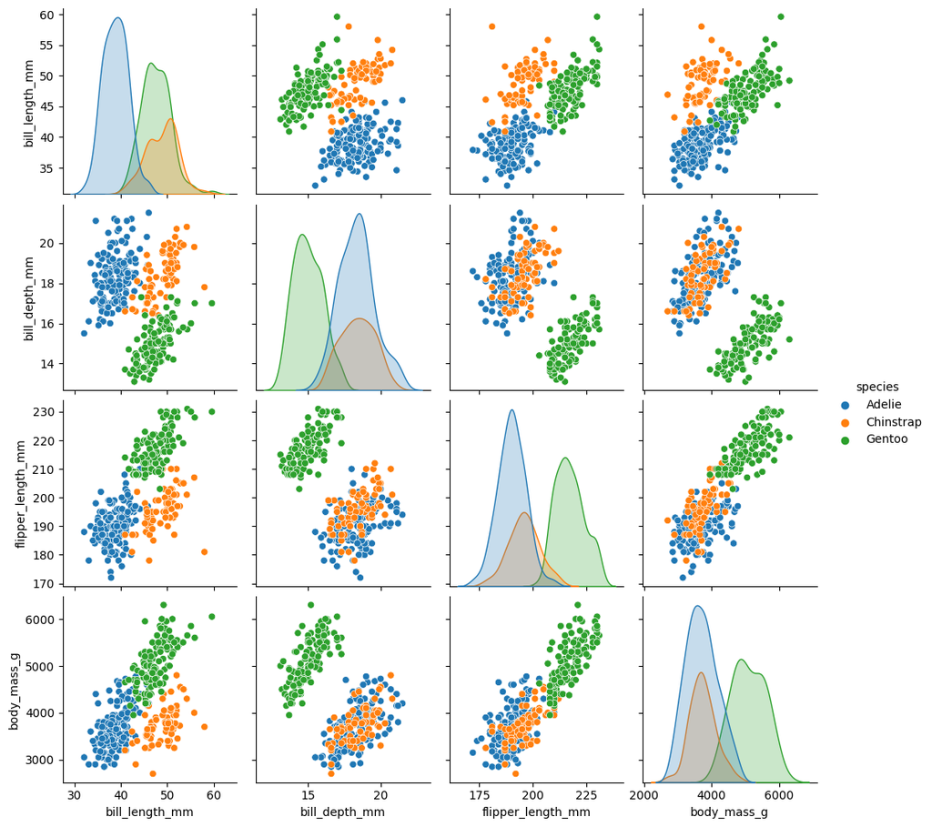

```python
# Insert your code here
sns.pairplot(penguins, hue='species')
```

### Task 4

Split the data into training and testing sets, ensuring that the same distribution of species exists in the split data sets as the distribution of species in the original dataframe.

```python
# Insert your code here
penguins['species'].value_counts()/len(penguins)
```

```
species
Adelie       0.438438
Gentoo       0.357357
Chinstrap    0.204204
Name: count, dtype: float64
```

```python
split = StratifiedShuffleSplit(n_splits=1, test_size=0.2, random_state=42)
for train_index, test_index in split.split(penguins, penguins['species']):
    strat_train_set = penguins.iloc[train_index]
    strat_test_set = penguins.iloc[test_index]
```

```python
penguins.shape
```

```
(333, 7)
```

```python
strat_train_set.shape
```

```
(266, 7)
```

```python
strat_test_set.shape
```

```
(67, 7)
```

```python
strat_train_set['species'].value_counts()/len(strat_train_set)
```

```
species
Adelie       0.439850
Gentoo       0.357143
Chinstrap    0.203008
Name: count, dtype: float64
```

```python
strat_test_set['species'].value_counts()/len(strat_test_set)
```

```
species
Adelie       0.432836
Gentoo       0.358209
Chinstrap    0.208955
Name: count, dtype: float64
```

### Task 5

Create a design matrix (`penguins_X`) and a label matrix (`penguins_y`) from the stratified training set.

```python
# Insert your code here
penguins_X = strat_train_set.drop('flipper_length_mm', axis=1)
penguins_y = strat_train_set['flipper_length_mm']
```

```python
penguins_X
```

|  | species | island | bill_length_mm | bill_depth_mm | body_mass_g | sex |
| --- | --- | --- | --- | --- | --- | --- |
| 268 | Gentoo | Biscoe | 44.9 | 13.3 | 5100.0 | Female |
| 205 | Chinstrap | Dream | 50.7 | 19.7 | 4050.0 | Male |
| 337 | Gentoo | Biscoe | 48.8 | 16.2 | 6000.0 | Male |
| 123 | Adelie | Torgersen | 41.4 | 18.5 | 3875.0 | Male |
| 38 | Adelie | Dream | 37.6 | 19.3 | 3300.0 | Female |
| ... | ... | ... | ... | ... | ... | ... |
| 24 | Adelie | Biscoe | 38.8 | 17.2 | 3800.0 | Male |
| 201 | Chinstrap | Dream | 49.8 | 17.3 | 3675.0 | Female |
| 43 | Adelie | Dream | 44.1 | 19.7 | 4400.0 | Male |
| 255 | Gentoo | Biscoe | 48.4 | 16.3 | 5400.0 | Male |
| 70 | Adelie | Torgersen | 33.5 | 19.0 | 3600.0 | Female |

266 rows × 6 columns

```python
penguins_y
```

```
268    213.0
205    203.0
337    222.0
123    202.0
38     181.0
       ...
24     180.0
201    198.0
43     196.0
255    220.0
70     190.0
Name: flipper_length_mm, Length: 266, dtype: float64
```

### Task 6

Create a pipeline to apply a `StandardScaler()` to all numeric values and a `OneHotEncoder()` to the categorical variables in `penguins_X`. Assign the resulting matrix to a variable called `penguins_prepared`.

```python
# Insert your code here
from sklearn.compose import ColumnTransformer
from sklearn.preprocessing import StandardScaler
from sklearn.preprocessing import OneHotEncoder

num_attribs = list(penguins_X.select_dtypes(include=[np.number]))
cat_attribs = list(penguins_X.select_dtypes(exclude=[np.number]))

# takes in sequence of tuples
full_pipeline = ColumnTransformer([
    ("num", StandardScaler(), num_attribs),
    ("cat", OneHotEncoder(), cat_attribs),
    ])

penguins_prepared = full_pipeline.fit_transform(penguins_X)
penguins_prepared
```

```
array([[ 0.16732502, -1.99231135,  1.08239437, ...,  0.        ,
         1.        ,  0.        ],
       [ 1.22705014,  1.25552054, -0.21564233, ...,  0.        ,
         0.        ,  1.        ],
       [ 0.87989881, -0.52063753,  2.19499725, ...,  0.        ,
         0.        ,  1.        ],
       ...,
       [ 0.02115604,  1.25552054,  0.21703657, ...,  0.        ,
         0.        ,  1.        ],
       [ 0.80681432, -0.46989015,  1.453262  , ...,  0.        ,
         0.        ,  1.        ],
       [-1.91558298,  0.90028893, -0.77194377, ...,  1.        ,
         1.        ,  0.        ]])
```

### Task 7

Fit a linear regression to penguins_prepared and penguins_y.

```python
# Insert your code here
from sklearn.linear_model import LinearRegression

lin_reg = LinearRegression()
lin_reg = lin_reg.fit(penguins_prepared, penguins_y)
lin_reg
```

```
LinearRegression()
```

```python
lin_reg.score(penguins_prepared,penguins_y)
```

```
0.8648816066728093
```

```python
lin_reg.coef_
```

```
array([ 2.36732292,  1.56722365,  4.83266084, -6.73818287, -5.87790293,
       12.61608579, -1.72638892, -0.08641165,  1.81280057,  0.06818294,
       -0.06818294])
```

### Task 8

Use the fitted model to show the predicted values for the first 5 rows of data.

```python
# Insert your code here
lin_reg.predict(penguins_prepared[:5])
```

```
array([215.01468587, 199.35012793, 224.24848666, 194.36658597,
       188.16116242])
```

### Task 9

```python
# Insert your code here
from sklearn.metrics import mean_squared_error
mean_squared_error(penguins_y, lin_reg.predict(penguins_prepared))
```

```
26.53905056522649
```

### Task 10

```python
# Insert your code here
penguins_y_test = lin_reg.predict(penguins_prepared)

final_mse = mean_squared_error(penguins_y, penguins_y_test)
final_rmse = np.sqrt(final_mse)
final_rmse
```

```
5.151606600394336
```